# Project 1

```r
knitr::opts_chunk$set(echo = TRUE)
library(ggplot2)
```

1.getNodes() is a function to generate nodes in an ad hoc network.

```r
getNodes = function(n){

  Nodes = matrix(runif(2*n,0,100), ncol = 2)
  colnames(Nodes) <- c("x","y")
  rownames(Nodes) <- 1:n

  return(Nodes)
}
```

test for getNodes() with set.seed()

```r
seeds = vector(length = 2, mode = "list")
set.seed(12345678)
seeds[[1]] = .Random.seed
a = getNodes(20)
a
```

```
##             x         y
## 1  87.4493237 29.982339
## 2  28.8790082 28.590068
## 3  94.7211719 41.237805
## 4  88.4520706 40.494738
## 5   0.8678354 38.975662
## 6  52.1891946 39.878085
## 7  39.8705438 47.910538
## 8  96.0019596 75.042876
## 9  81.3903614 30.976955
## 10  9.2448982 69.445912
## 11 22.5922084 93.313683
## 12 99.3158175  6.309057
## 13 22.4852071 37.157258
## 14 54.6598573 60.657133
## 15 83.7353629 95.841602
## 16 82.4399956 24.268543
## 17 86.4207304 62.634850
## 18 70.1360101 90.394736
## 19 99.4644627 69.639022
## 20 56.2150992 27.496029
```

```r
seeds[[2]] = .Random.seed
b = getNodes(20)
b
```

```
##             x         y
## 1  42.2683378 29.196525
## 2  59.7569945 12.608106
## 3   2.0711658  9.509243
## 4  21.3178845 52.901605
## 5  40.1602007 50.156703
## 6  85.1543210 45.360089
## 7  24.0498578 87.554870
## 8  64.2527189 15.973032
## 9   1.4492429 53.081874
## 10 76.3725982 65.129062
## 11 65.0854883 53.602606
## 12 75.3058456 47.912122
## 13 66.9060568 35.759815
## 14 79.4419097 12.203396
## 15 88.7776134  6.747329
## 16 29.4328171 90.223491
## 17 29.6154688 47.912027
## 18 81.8685511 62.517564
## 19 37.0807810 30.105379
## 20  0.1431841 81.965464
```

```r
c = list()
for(i in 1:5){
  seeds[[i]] = .Random.seed
  c[[i]] = getNodes(20)

}
c
```

```
## [[1]]
##            x         y
## 1  64.919092 34.356140
## 2  15.313280 86.181739
## 3  64.891547 83.271387
## 4  21.879852 56.106832
## 5  18.788627 66.519449
## 6  27.486245  1.733445
## 7   3.208993 78.660279
## 8  88.374019 47.425148
## 9  69.765118 43.476751
## 10 35.661908 74.361398
## 11 19.894567 55.727267
## 12 61.646260 58.249529
## 13 65.506061 34.141898
```

[output cut: 99 more lines]

findTranMat() is a function to find the transition matrix based on a distance matrix and a value for R.

```r
findTranMat = function(mat, R){
  n = dim(mat)[1]*dim(mat)[2]
  trans.mat = mat
  for(i in 1:n){
    trans.mat[i] = mat[i]<=R
  }
  trans.mat = apply(trans.mat, 1, "/", rowSums(trans.mat))
  return(trans.mat)
}
```

getEigen2() is a function to return the second largest eigenvalue of a matrix.

```r
getEigen2 = function(mat){

  eigenvalues = eigen(mat)$values
  SecondLargest = eigenvalues[order(-eigenvalues)[2]]
  return(SecondLargest)

}
```

findRange() is a function to find the range of Rc to search over based on possible values.

```r
findRange = function(mat){
  n = dim(mat)[1]
  IgnoreDiag = mat
  diag(IgnoreDiag) = NA

  IgnoreDiag = IgnoreDiag[which(!is.na(IgnoreDiag))]

  newMat = matrix(IgnoreDiag,nrow = n, byrow = TRUE)

  Min = max(apply(newMat,1,min))
  Max = min(apply(mat,1,max))
  Min.Max = c(Min,Max)

  return(Min.Max)

}
```

2.(2)findRc() is a function to find the smallest radius, Rc, such that the network is completely connected.

```r
findRc = function(nodes, tol = 0.05){

  distBNodes1 = as.matrix(dist(nodes))

  lower = findRange(distBNodes1)[1]
  upper = findRange(distBNodes1)[2]
  Radius = sum(c(lower,upper))/2
  TranMat = findTranMat(distBNodes1,Radius)
  EigenValue = getEigen2(TranMat)


  while(abs(upper-lower) > tol){

    TranMat = findTranMat(distBNodes1,Radius)
    EigenValue = getEigen2(TranMat)

    if(Mod(EigenValue) != EigenValue){
      upper = Radius
    }else{
      lower = Radius
    }
    Radius = sum(c(lower,upper))/2
  }
  return(upper)

}
```

```r
x = c(0,0,1,1,10,10,11,11)
y = c(0,1,0,1,0,1,0,1)
yong = matrix(c(x,y),ncol = 2)
findRc(yong,tol = 1)
```

```
## [1] 10.04988
```

nodeDensity() is a function to take two inputs of numeric vectors of the same length, and returns a numeric vector of values that are proportional to node density at the (x,y) pairs.

```r
nodeDensity = function (x, y) {
# x is a numeric vector
# y is a numeric vector the same length as x
# z is returned.
# It is a numeric vector that provides the value of the node density function

# Check the inputs for the correct format
if (mode(x) != "numeric" | mode(y) != "numeric") stop("x and y must be numeric")
if (length(x) != length(y)) stop("x and y must be same length")

  a = 3
  b = 1
  band = 15
  bank = 1
  inBoundary = (0 <= x & x <= 100) &
             (0 <= y & y <= 100 & y < sqrt(110^2 - x^2))

  river = abs(sqrt(x^2 + y^2) - 60)
  hiArea = river> bank & river < band & inBoundary

  hiDensity = a * cos(river[hiArea] * pi / (2 * band)) + b

  z = b * inBoundary
  z[hiArea] = hiDensity
  z[river <= bank] = 0
  z
}
```

test for nodeDensity

```r
nodeDensity(41:60,rep(5,20))
```

```
##  [1] 1.000000 1.000000 1.000000 1.000000 1.086987 1.398100 1.704981
##  [8] 2.004297 2.292793 2.567329 2.824916 3.062745 3.278221 3.468991
## [15] 3.632967 3.768354 3.873667 3.947748 0.000000 0.000000
```

```r
c = getNodes(20)
nodeDensity(c[,1],c[,2])
```

```
##        1        2        3        4        5        6        7        8
## 1.000000 1.000000 0.000000 1.000000 1.876244 1.000000 1.000000 1.000000
##        9       10       11       12       13       14       15       16
## 0.000000 1.000000 1.946234 1.000000 1.000000 1.000000 1.000000 1.000000
##       17       18       19       20
## 1.000000 3.872171 1.000000 1.000000
```

test

```r
x = c(1, 2, 3)
y = c(5, 5, 2)

nodes3 = matrix(c(x,y), nrow = 3)

distBNodes = as.matrix(dist(nodes3))

# If R = 3.5 then
findTranMat(distBNodes, 3.5)
```

```
##           1         2         3
## 1 0.5000000 0.5000000 0.0000000
## 2 0.3333333 0.3333333 0.3333333
## 3 0.0000000 0.5000000 0.5000000
```

```r
#returns
tranR3.5 = matrix(c(1/2, 1/2, 0, 1/3, 1/3, 1/3, 0, 01/2, 1/2),
                  byrow = TRUE, nrow = 3)


# and
getEigen2(tranR3.5)
```

```
## [1] 0.5
```

```r
#returns 0.5

# If R = 2 then
findTranMat(distBNodes, 2)
```

```
##     1   2 3
## 1 0.5 0.5 0
## 2 0.5 0.5 0
## 3 0.0 0.0 1
```

```r
#returns
tranR2 = matrix(c(1/2, 1/2, 0, 1/2, 1/2, 0, 0, 0, 1),
                byrow = TRUE, nrow = 3)

#And
getEigen2(tranR2)
```

```
## [1] 1
```

```r
#returns 1

#Additionally,
findRange(distBNodes)
```

```
## [1] 3.162278 3.162278
```

```r
#returns approximately
# 3.16227766 3.16227766

#AND
findRc(nodes3, tol = 0.001)
```

```
## [1] 3.162278
```

```r
# Returns
# 3.162

################
#ANother example
nodes5 = matrix(c(1,3,2,1,3,3,3,2,0,0), nrow =5)
distBNodes5 = as.matrix(dist(nodes5))

findTranMat(distBNodes5, 2)
```

```
##           1         2         3   4   5
## 1 0.3333333 0.3333333 0.3333333 0.0 0.0
## 2 0.3333333 0.3333333 0.3333333 0.0 0.0
## 3 0.3333333 0.3333333 0.3333333 0.0 0.0
## 4 0.0000000 0.0000000 0.0000000 0.5 0.5
## 5 0.0000000 0.0000000 0.0000000 0.5 0.5
```

```r
#returns
tranR2 = matrix(c(1/3, 1/3, 1/3, 0, 0,
                  1/3, 1/3, 1/3, 0, 0,
                  1/3, 1/3, 1/3, 0, 0,
                  0, 0, 0, 1/2, 1/2,
                  0, 0, 0, 1/2, 1/2),
                byrow = TRUE, nrow = 5)

getEigen2(tranR2)
```

```
## [1] 1
```

```r
# returns 1

#Additionally,
findRange(distBNodes5)
```

```
## [1] 2.000000 2.236068
```

```r
#returns approximately
# 2   2.23608

#Also
tranR2.23 = findTranMat(distBNodes5, 2.23)
getEigen2(tranR2.23)
```

```
## [1] 1
```

```r
# returns 1

#AND
findRc(nodes5, tol = 0.0001)
```

```
## [1] 2.236068
```

```r
# Returns approximately
#2.23608

# Note that with the tolerances we want to only check
# values that are 0.0001 apart in our Rc range
```

3.Generate 1000 networks and for each find the value for Rc. Examine the distribution of these Rc values.

test the network with size 20

```r
Rc = c()
seeds = vector(length = 2, mode = "list")
set.seed(12345678)
n = 20
networks = vector("list",1000)
for(i in 1:1000){
  seeds[[i]] = .Random.seed
  networks[[i]] = getNodes(n)
}
for(i in 1:1000){
  Rc[i] = findRc(networks[[i]])
}
Rc
```

```
##    [1] 64.24232 63.66989 66.03767 61.84596 68.60262 64.95301 68.32649
##    [8] 72.91352 64.91150 79.88781 66.33371 69.50506 67.57853 56.30006
##   [15] 59.86474 58.05912 60.81810 63.88150 58.85623 66.76791 59.92015
##   [22] 63.80753 49.69549 66.57619 56.70000 66.98719 56.66257 68.65215
##   [29] 58.44763 75.43611 65.71654 65.22771 67.24655 65.14783 54.47228
##   [36] 61.12652 61.52858 60.77461 68.49891 68.92252 59.75548 71.01398
##   [43] 66.15302 57.28601 63.21200 64.85416 71.70538 74.56849 70.13629
##   [50] 65.59519 69.34615 59.30609 71.30897 71.61983 68.21514 64.98694
##   [57] 61.58801 80.28118 55.90353 68.78909 65.96597 70.41603 63.89789
##   [64] 64.45382 58.54556 57.90118 45.38933 69.74280 62.15363 77.06341
##   [71] 77.25305 72.23096 64.90172 68.46104 56.35009 69.79085 65.98539
##   [78] 64.70804 54.70975 71.17529 65.62973 56.51522 58.26897 52.40495
##   [85] 69.87071 59.87870 55.52843 62.54086 63.98640 75.19244 69.52029
##   [92] 62.26186 62.76489 60.78772 64.81751 69.04845 66.85784 68.69205
##   [99] 60.65259 76.25663 61.47687 66.18695 58.33133 63.37002 61.82641
```

[output cut: 128 more lines]

test for the network with size 50

```r
Rc2 = c()
seeds = vector(length = 2, mode = "list")
set.seed(12345678)
m = 50
networks2 = vector("list",1000)
for(i in 1:1000){
  seeds[[i]] = .Random.seed
  networks2[[i]] = getNodes(m)
}
for(i in 1:1000){
  Rc2[i] = findRc(networks2[[i]])
}
Rc2
```

```
##    [1] 67.97465 53.94221 65.98844 70.34261 63.55861 61.78264 63.09170
##    [8] 64.03471 64.73292 65.21047 73.87765 68.99696 66.96354 66.84837
##   [15] 57.11390 73.12871 67.64326 63.26794 66.86416 70.92538 63.27401
##   [22] 71.42209 66.51836 71.63556 62.69402 65.24153 63.11573 57.05548
##   [29] 74.37610 69.73165 75.44356 59.89089 64.00573 63.63962 70.11032
##   [36] 69.55173 64.16968 67.49262 69.39708 61.38848 69.70316 65.70826
##   [43] 63.22660 70.49973 65.42968 57.63328 61.39314 71.42438 65.65585
##   [50] 67.86468 67.76611 71.24200 69.35044 66.71732 69.80672 66.37624
##   [57] 70.30954 60.23361 69.33738 59.24168 61.00479 65.61188 68.76227
##   [64] 64.15518 66.99202 54.97749 60.21364 69.22544 68.41513 64.61633
##   [71] 62.75879 64.89662 64.12256 60.86582 63.74965 65.15956 62.26226
##   [78] 67.86950 61.68513 64.90860 67.26266 69.89655 67.86115 68.61020
##   [85] 57.12261 66.98580 64.64072 65.62230 68.97535 66.85649 65.02917
##   [92] 66.02181 63.65403 71.63560 67.84368 69.78907 75.65119 70.05773
##   [99] 72.08830 62.54798 68.54256 64.08659 71.28779 70.81007 70.73794
```

[output cut: 128 more lines]

plot for comparing Rc with different size

```r
plotRc = function(Rc1, Rc2 = NULL, bw = 2,
           title = 'Compare Rc with different size')
{
    Rcs = data.frame(
      Rc12 = c(Rc1, Rc2),
      strat = rep(c(1,2),
                  times = c(length(Rc1), length(Rc2)))
      )
    require(ggplot2)
    ggplot(data = Rcs) +
      geom_density(aes(x = Rc12, y = ..density..,
                       color = factor(strat)),
                   bw = bw) +
      scale_x_continuous("Smallest Radius(Rc) for 1000 Networks") +
      ggtitle(title) +
      scale_colour_manual(values = c(1,2), name = 'Density', labels = c('Rc1','Rc2'))
}
```

comparison Rc and RcTwo with different size

```r
summary(Rc)
```

```
##    Min. 1st Qu.  Median    Mean 3rd Qu.    Max.
##   45.39   60.30   64.75   64.81   68.79   88.59
```

```r
summary(Rc2)
```

```
##    Min. 1st Qu.  Median    Mean 3rd Qu.    Max.
##   53.16   63.67   66.43   66.55   69.21   82.58
```

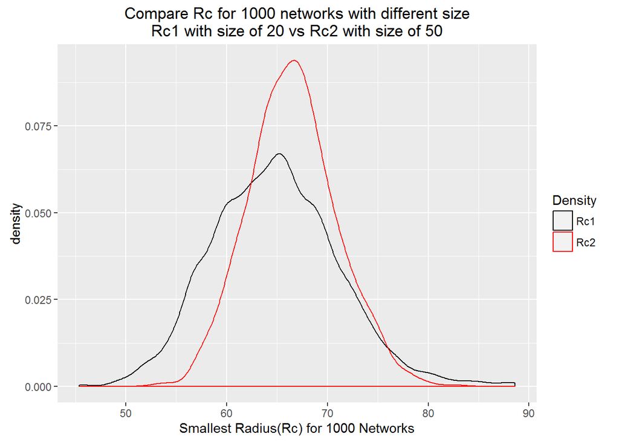

```r
plotRc(Rc, Rc2, bw = 1,
          title = "Compare Rc for 1000 networks with different size\nRc1 with size of 20 vs Rc2 with size of 50")
```

```r
summary(Rc)
```

```
##    Min. 1st Qu.  Median    Mean 3rd Qu.    Max.
##   45.39   60.30   64.75   64.81   68.79   88.59
```

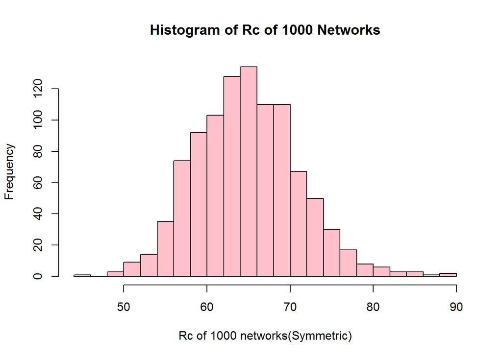

```r
Histogram = hist(Rc, breaks = 20, col = "pink", xlab = "Rc of 1000 networks(Symmetric)", main = "Histogram of Rc of 1000 Networks")
```

```r
print("The the distribution of Rc of 1000 Networks is 'Symmetric'.")
```

```
## [1] "The the distribution of Rc of 1000 Networks is 'Symmetric'."
```

```r
Histogram
```

```
## $breaks
##  [1] 44 46 48 50 52 54 56 58 60 62 64 66 68 70 72 74 76 78 80 82 84 86 88
## [24] 90
##
## $counts
##  [1]   1   0   3   9  14  35  74  92 103 128 134 110 110  67  50  30  17
## [18]   8   6   3   3   1   2
##
## $density
##  [1] 0.0005 0.0000 0.0015 0.0045 0.0070 0.0175 0.0370 0.0460 0.0515 0.0640
## [11] 0.0670 0.0550 0.0550 0.0335 0.0250 0.0150 0.0085 0.0040 0.0030 0.0015
## [21] 0.0015 0.0005 0.0010
##
## $mids
##  [1] 45 47 49 51 53 55 57 59 61 63 65 67 69 71 73 75 77 79 81 83 85 87 89
##
## $xname
## [1] "Rc"
##
## $equidist
## [1] TRUE
##
## attr(,"class")
## [1] "histogram"
```

find the 4 Rc values that coincide with (or are close to) the minimum, maximum, median, and mean Rc value

```r
Min = min(Rc)
Median = median(Rc)
Mean = mean(Rc)
Max = max(Rc)

Min
```

```
## [1] 45.38933
```

```r
Median
```

```
## [1] 64.74742
```

```r
Mean
```

```
## [1] 64.80816
```

```r
Max
```

```
## [1] 88.58908
```

```r
i = which(abs(Rc-Min)<=0.005)
j = which(abs(Rc-Median)<=0.005)
k = which(abs(Rc-Mean)<=0.005)
l = which(abs(Rc-Max)<=0.005)
if(length(i)>1 | length(j)>1 | length(k)>1 | length(l)>1){
  i = i[1]
  j = j[1]
  k = k[1]
  l = l[1]
}
CloseMin = Rc[i]
CloseMedian = Rc[j]
CloseMean = Rc[k]
CloseMax = Rc[l]

c(i, CloseMin)
```

```
## [1] 67.00000 45.38933
```

```r
c(j, CloseMedian)
```

```
## [1] 262.00000  64.75066
```

```r
c(k, CloseMean)
```

```
## [1] 996.00000  64.81103
```

```r
c(l, CloseMax)
```

```
## [1] 600.00000  88.58908
```

test for Min Median Mean Max Rc with size of twenty of the network

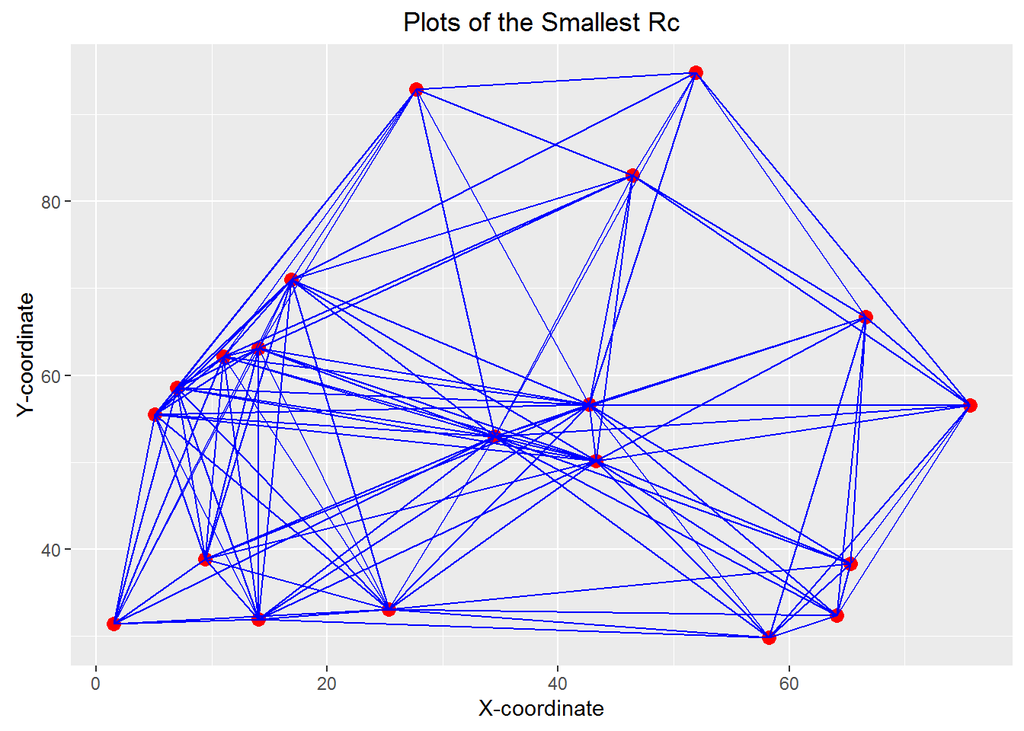

```r
mindf = data.frame(networks[i])
comb = combn(nrow(mindf), 2)
connected = comb[,which(as.numeric(dist(networks[[i]]))<=Rc[i])]
connections = data.frame(
  from = mindf[connected[1, ], 1:2],
  to = mindf[connected[2, ], 1:2]
)
names(connections) = c("x1", "y1", "x2", "y2")

plot1 = ggplot(mindf,aes(x=mindf$x,y=mindf$y)) +
  geom_point(col = "red", size = 3) +
  geom_segment(data = connections, aes(x=x1, y=y1, xend=x2, yend=y2), col="blue") +
  labs(x = "X-coordinate", y = "Y-coordinate", title = "Plots of the Smallest Rc")
plot1
```

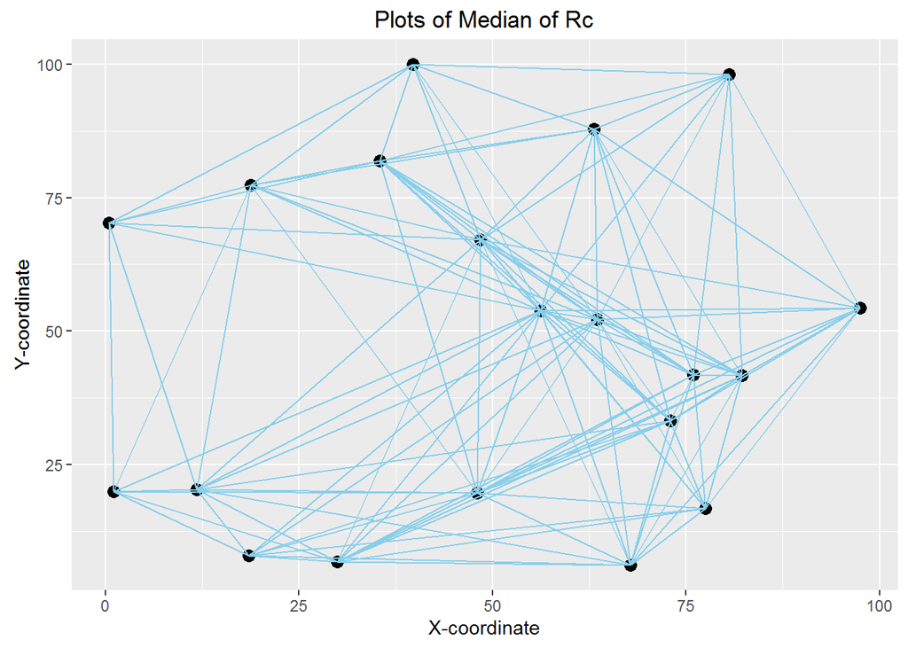

```r
mediandf = data.frame(networks[j])
comb2 = combn(nrow(mediandf), 2)
connected2 = comb2[,which(as.numeric(dist(networks[[j]]))<=Rc[j])]
connections2 = data.frame(
  from = mediandf[connected2[1, ], 1:2],
  to = mediandf[connected2[2, ], 1:2]
)
names(connections2) = c("x1", "y1", "x2", "y2")

plot2 = ggplot(mediandf,aes(x=mediandf$x,y=mediandf$y)) +
  geom_point(col = "black", size = 3) +
  geom_segment(data = connections2, aes(x=x1, y=y1, xend=x2, yend=y2), col="skyblue") +
  labs(x = "X-coordinate", y = "Y-coordinate", title = "Plots of Median of Rc")
plot2
```

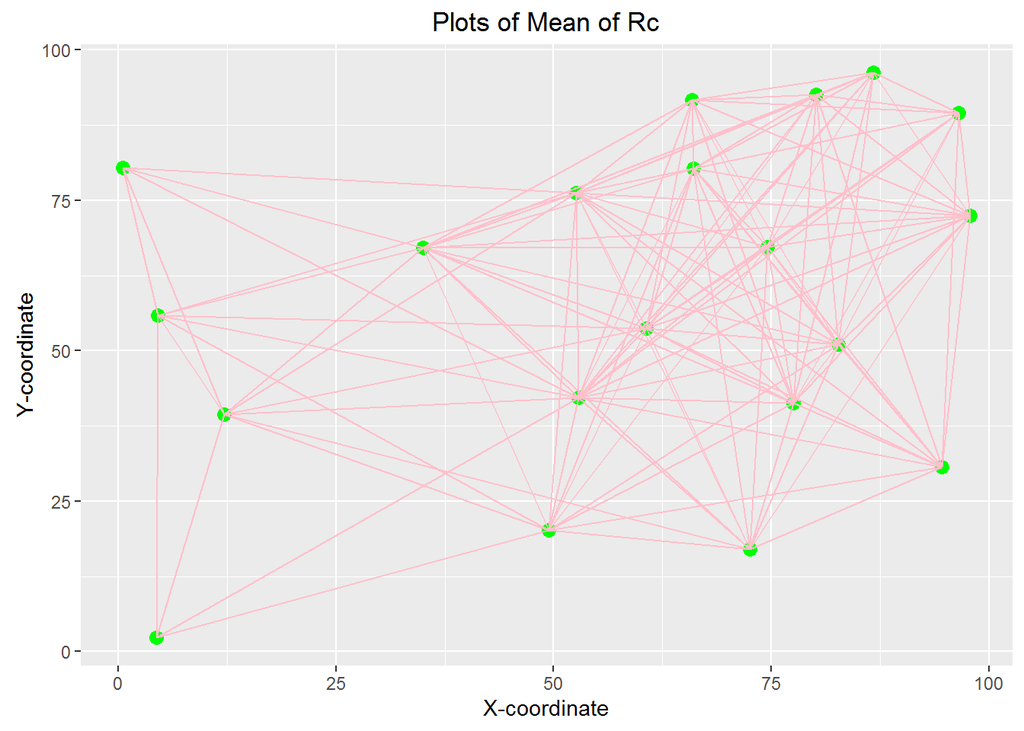

```r
meandf = data.frame(networks[k])
comb3 = combn(nrow(meandf), 2)
connected3 = comb[,which(as.numeric(dist(networks[[k]]))<=Rc[k])]
connections3 = data.frame(
  from = meandf[connected3[1, ], 1:2],
  to = meandf[connected3[2, ], 1:2]
)
names(connections3) = c("x1", "y1", "x2", "y2")

plot3 = ggplot(meandf,aes(x=meandf$x,y=meandf$y)) +
  geom_point(col = "green", size = 3) +
  geom_segment(data = connections3, aes(x=x1, y=y1, xend=x2, yend=y2), col="pink") +
  labs(x = "X-coordinate", y = "Y-coordinate", title = "Plots of Mean of Rc")
plot3
```

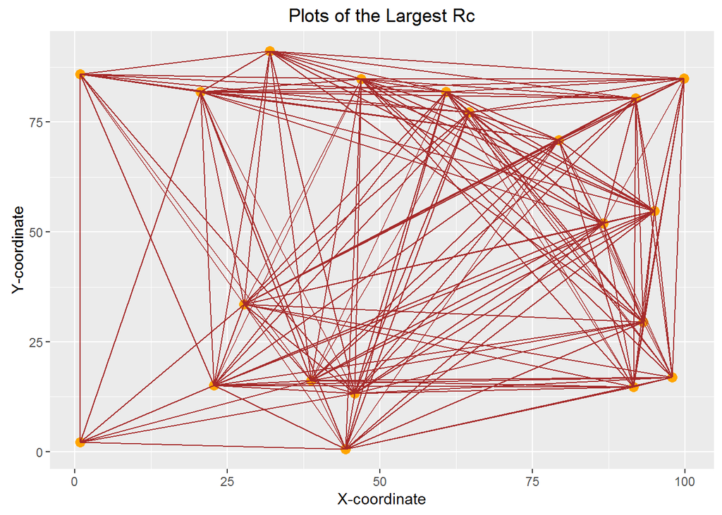

```r
maxdf = data.frame(networks[l])
comb4 = combn(nrow(maxdf), 2)
connected4 = comb[,which(as.numeric(dist(networks[[l]]))<=Rc[l])]
connections4 = data.frame(
  from = maxdf[connected4[1, ], 1:2],
  to = maxdf[connected4[2, ], 1:2]
)
names(connections4) = c("x1", "y1", "x2", "y2")

plot4 = ggplot(maxdf,aes(x=maxdf$x,y=maxdf$y)) +
  geom_point(col = "orange", size = 3) +
  geom_segment(data = connections4, aes(x=x1, y=y1, xend=x2, yend=y2), col="brown") +
  labs(x = "X-coordinate", y = "Y-coordinate", title = "Plots of the Largest Rc")
plot4
```